# Homework 5

Araks Karapetyan

21.11.2018

Read the file Songs which contains data about different sogns’ parameters and the variable Top10 indicates whether the song has been in the list of top10 songs. Your task will be building a model to predict this.

```r
songs <- read.csv("songs.csv")
str(songs)
```

```
## 'data.frame':    7574 obs. of  34 variables:
##  $ timesignature           : int  3 4 4 4 4 4 4 4 4 4 ...
##  $ timesignature_confidence: num  0.853 1 1 1 0.788 1 0.968 0.861 0.622 0.938 ...
##  $ loudness                : num  -4.26 -4.05 -3.57 -3.81 -4.71 ...
##  $ tempo                   : num  91.5 140 160.5 97.5 140.1 ...
##  $ tempo_confidence        : num  0.953 0.921 0.489 0.794 0.286 0.347 0.273 0.83 0.018 0.929 ...
##  $ key                     : int  11 10 2 1 6 4 10 5 9 11 ...
##  $ key_confidence          : num  0.453 0.469 0.209 0.632 0.483 0.627 0.715 0.423 0.751 0.602 ...
##  $ energy                  : num  0.967 0.985 0.99 0.939 0.988 ...
##  $ pitch                   : num  0.024 0.025 0.026 0.013 0.063 0.038 0.026 0.033 0.027 0.004 ...
##  $ timbre_0_min            : num  0.002 0 0.003 0 0 ...
##  $ timbre_0_max            : num  57.3 57.4 57.4 57.8 56.9 ...
##  $ timbre_1_min            : num  -6.5 -37.4 -17.2 -32.1 -223.9 ...
##  $ timbre_1_max            : num  171 171 171 221 171 ...
##  $ timbre_2_min            : num  -81.7 -149.6 -72.9 -138.6 -147.2 ...
```

[output cut: 20 more lines]

(2 points) Look for the summaries of the variables and tell whether there is a need to standardize the variables for to run knn

```r
summary(songs)
```

```
##  timesignature   timesignature_confidence    loudness
##  Min.   :0.000   Min.   :0.0000           Min.   :-42.451
##  1st Qu.:4.000   1st Qu.:0.8193           1st Qu.:-10.847
##  Median :4.000   Median :0.9790           Median : -7.649
##  Mean   :3.894   Mean   :0.8533           Mean   : -8.817
##  3rd Qu.:4.000   3rd Qu.:1.0000           3rd Qu.: -5.640
##  Max.   :7.000   Max.   :1.0000           Max.   :  1.305
##      tempo        tempo_confidence      key         key_confidence
##  Min.   :  0.00   Min.   :0.0000   Min.   : 0.000   Min.   :0.0000
##  1st Qu.: 88.86   1st Qu.:0.3720   1st Qu.: 2.000   1st Qu.:0.2040
##  Median :103.27   Median :0.7015   Median : 6.000   Median :0.4515
##  Mean   :107.35   Mean   :0.6229   Mean   : 5.385   Mean   :0.4338
##  3rd Qu.:124.80   3rd Qu.:0.8920   3rd Qu.: 9.000   3rd Qu.:0.6460
##  Max.   :244.31   Max.   :1.0000   Max.   :11.000   Max.   :1.0000
##      energy            pitch          timbre_0_min     timbre_0_max
##  Min.   :0.00002   Min.   :0.00000   Min.   : 0.000   Min.   :12.58
##  1st Qu.:0.50014   1st Qu.:0.00300   1st Qu.: 0.000   1st Qu.:53.12
##  Median :0.71816   Median :0.00700   Median : 0.027   Median :55.53
##  Mean   :0.67547   Mean   :0.01082   Mean   : 4.123   Mean   :54.46
##  3rd Qu.:0.88740   3rd Qu.:0.01400   3rd Qu.: 2.772   3rd Qu.:57.08
##  Max.   :0.99849   Max.   :0.54100   Max.   :48.353   Max.   :64.01
##   timbre_1_min      timbre_1_max     timbre_2_min      timbre_2_max
##  Min.   :-333.72   Min.   :-74.37   Min.   :-324.86   Min.   : -0.832
##  1st Qu.:-160.12   1st Qu.:171.13   1st Qu.:-167.64   1st Qu.:100.519
##  Median :-107.75   Median :194.40   Median :-136.60   Median :129.908
##  Mean   :-110.79   Mean   :212.34   Mean   :-136.89   Mean   :136.673
##  3rd Qu.: -59.71   3rd Qu.:239.24   3rd Qu.:-106.51   3rd Qu.:166.121
##  Max.   : 123.73   Max.   :549.97   Max.   :  34.57   Max.   :397.095
##   timbre_3_min      timbre_3_max     timbre_4_min      timbre_4_max
##  Min.   :-495.36   Min.   : 12.85   Min.   :-207.07   Min.   : -0.651
##  1st Qu.:-226.87   1st Qu.:127.14   1st Qu.: -77.69   1st Qu.: 83.966
##  Median :-170.61   Median :189.50   Median : -63.83   Median :107.422
##  Mean   :-186.11   Mean   :211.81   Mean   : -65.28   Mean   :108.227
##  3rd Qu.:-131.56   3rd Qu.:290.72   3rd Qu.: -51.34   3rd Qu.:130.286
##  Max.   : -21.55   Max.   :499.62   Max.   :  51.43   Max.   :257.801
##   timbre_5_min      timbre_5_max     timbre_6_min       timbre_6_max
##  Min.   :-262.48   Min.   :-22.41   Min.   :-152.170   Min.   : 12.70
##  1st Qu.:-113.58   1st Qu.: 84.64   1st Qu.: -94.792   1st Qu.: 59.04
##  Median : -95.47   Median :119.90   Median : -80.418   Median : 70.47
##  Mean   :-104.00   Mean   :127.04   Mean   : -80.944   Mean   : 72.17
```

[output cut: 8 more lines]

```
##  Max.   :   5.153   Max.   :214.82   Max.   :  -2.382   Max.   :144.99
##   timbre_9_min      timbre_9_max     timbre_10_min     timbre_10_max
##  Min.   :-149.51   Min.   :  8.415   Min.   :-208.82   Min.   : -6.359
##  1st Qu.: -70.28   1st Qu.: 53.037   1st Qu.:-105.13   1st Qu.: 39.196
##  Median : -58.65   Median : 65.935   Median : -83.07   Median : 50.895
##  Mean   : -59.52   Mean   : 68.028   Mean   : -87.34   Mean   : 55.521
##  3rd Qu.: -47.70   3rd Qu.: 81.267   3rd Qu.: -64.52   3rd Qu.: 66.593
##  Max.   :   1.14   Max.   :161.518   Max.   : -10.64   Max.   :192.417
##  timbre_11_min      timbre_11_max    Top10
##  Min.   :-145.599   Min.   :  7.20   No :6455
##  1st Qu.: -58.058   1st Qu.: 38.98   Yes:1119
##  Median : -50.892   Median : 46.44
##  Mean   : -50.868   Mean   : 47.49
##  3rd Qu.: -43.292   3rd Qu.: 55.03
##  Max.   :  -6.497   Max.   :110.27
```

```r
songs
```

[output not shown]

[output cut: 20580 more lines]

```r
#Yes, we need to standardize.
sc <- scale(songs[,1:33])
sc <- as.data.frame(sc)
songs[,1:33] <- sc
songs
```

[output not shown]

[output cut: 20580 more lines]

(5 points) Use the package caret to identify the optimal number of K. Run repeated k-fold cross validation. Use the accuracy for defining which number is the best. Do not forget to set seed

```r
library(caret)
set.seed(1)
ctrl <- trainControl(method = "cv", number = 10)
knn_s <- train(Top10~., data = songs, method = "knn", trControl = ctrl, preProcess = c("center", "scale"), tuneLength = 10)
knn_s$results
```

```
##     k  Accuracy     Kappa  AccuracySD    KappaSD
## 1   5 0.8451307 0.2083918 0.007462803 0.04065056
## 2   7 0.8533124 0.1968584 0.004436879 0.03178215
## 3   9 0.8539722 0.1755435 0.004810888 0.03646521
## 4  11 0.8570086 0.1692960 0.004893044 0.04226356
## 5  13 0.8572731 0.1501323 0.005124964 0.05090749
## 6  15 0.8592538 0.1551646 0.004285681 0.04437406
## 7  17 0.8578015 0.1422664 0.004321939 0.04377029
## 8  19 0.8591210 0.1422660 0.004936957 0.04957361
## 9  21 0.8596503 0.1440507 0.005167189 0.04390584
## 10 23 0.8596511 0.1397649 0.005027992 0.05030095
```

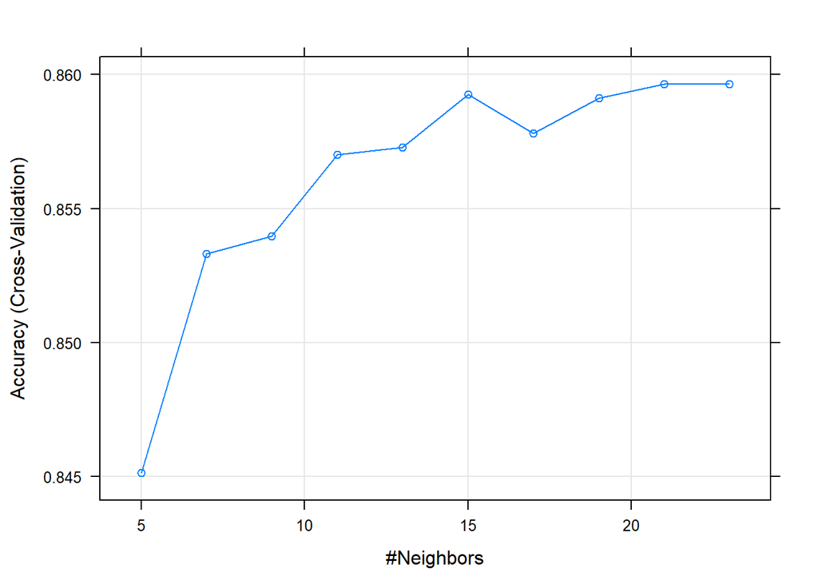

```r
plot(knn_s)
```

```r
#The best value for k is 23 as it has the highest accuracy rate.
```

(8 points) Divide the data into Train (80% of cases) and Test (20% of cases) so that the distrubution of the variable Top10 does not change. Based on the results in the previous problem, choose the most optimal number of K. Run Knn classification using the package class saving predicted probabilities.

```r
library(class)
set.seed(1)
index <- createDataPartition(songs$Top10, p = 0.8, list = F)
Train <- songs[index,]
Test <- songs[-index,]
knn_op <- knn(Train[, -34], Test[, -34], cl = Train$Top10, k = 23, prob = T)
```

(5 points) Solve the same classification problem using decision tree and plot the tree displaying the number of cases in each node,

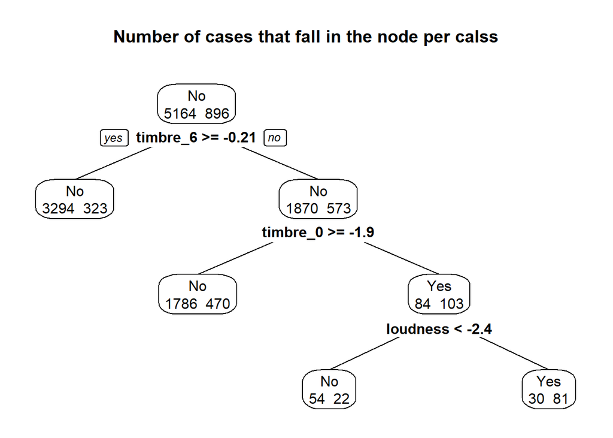

```r
library(rpart)
library(rpart.plot)
model <- rpart(Top10~., data = Train)
prp(model, type = 2, extra = 1, main = "Number of cases that fall in the node per calss")
```

(10 points) Build Confusion matrix for both models (knn and decision tree), compare and comment on all the accuracy measures. For knn use, both predicted classes and predicted probabilities in constructing the matrix.

Hint: when you use the predicted probabilities from the knn model, try to take different threshold values and comment what is the optimal one.(0.5 might not work,)

```r
#knn predicted probabilities
prob_knn<-attr(knn_op, "prob")
pred_knn = factor(ifelse(prob_knn>0.8,"Yes","No"))
confusionMatrix(pred_knn, Test$Top10, positive = "Yes")
```

```
## Confusion Matrix and Statistics
##
##           Reference
## Prediction  No Yes
##        No  301 143
##        Yes 990  80
##
##                Accuracy : 0.2517
##                  95% CI : (0.23, 0.2743)
##     No Information Rate : 0.8527
##     P-Value [Acc > NIR] : 1
##
##                   Kappa : -0.1587
##  Mcnemar's Test P-Value : <2e-16
##
##             Sensitivity : 0.35874
##             Specificity : 0.23315
##          Pos Pred Value : 0.07477
##          Neg Pred Value : 0.67793
##              Prevalence : 0.14729
##          Detection Rate : 0.05284
##    Detection Prevalence : 0.70674
##       Balanced Accuracy : 0.29595
##
##        'Positive' Class : Yes
##
```

```r
#Accuracy is 0.2517 which is bad.
#Sensitivity is 0.35874 which means that we accurately predicted 35.8% of the songs were included in the top10 and they were actually on the list.
#Specificity is 0.23315 which means that we accurately predicted 23.3% of the songs were included in the top10 and they were actually not on the list.
#PPV is 0.07477 which means that we predicted 7.47% of the songs were on the list of top10 songs and our prediction was right.
#NPV is 0.67793 which means that we predicted 67.7% of the songs were on the list of top10 songs and our prediction was wrong.

#knn predicted class
confusionMatrix(knn_op, Test$Top10, positive = "Yes")
```

```
## Confusion Matrix and Statistics
##
##           Reference
## Prediction   No  Yes
##        No  1283  211
##        Yes    8   12
##
##                Accuracy : 0.8554
##                  95% CI : (0.8366, 0.8727)
##     No Information Rate : 0.8527
##     P-Value [Acc > NIR] : 0.4029
##
##                   Kappa : 0.0764
##  Mcnemar's Test P-Value : <2e-16
##
##             Sensitivity : 0.053812
##             Specificity : 0.993803
##          Pos Pred Value : 0.600000
##          Neg Pred Value : 0.858768
##              Prevalence : 0.147292
##          Detection Rate : 0.007926
##    Detection Prevalence : 0.013210
##       Balanced Accuracy : 0.523807
##
##        'Positive' Class : Yes
##
```